# PEC3_diegoserranoventurini

[figure not shown]

M2.855 · Modelos avanzados de minería de datos · PEC3

2018-1 · Máster universitario en Ciencia de datos (Data science)

Estudios de Informática, Multimedia y Telecomunicación

# PEC 3: Métodos supervisados

En esta práctica veremos diferentes métodos supervisados aplicados sobre el conjunto de datos [Fashion MNIST](https://github.com/zalandoresearch/fashion-mnist) y trataremos de optimizar diferentes métricas.

0. Carga de datos
1. $k$ vecinos más cercanos
2. Support vector machines
3. Redes neuronales
4. Optimización de métricas

**Importante: Cada uno de los ejercicios puede suponer varios minutos de ejecución, por lo que la entrega debe hacerse en formato notebook y en formato html donde se vea el código y los resultados y comentarios de cada ejercicio. Para exportar el notebook a html puede hacerse desde el menú File $\to$ Download as $\to$ HTML.**

## 0. Carga de datos

El conjunto de datos Fashion MNIST proporcionado por Zalando consta de 70.000 imágenes con 10 clases diferentes de ropa repartidas uniformemente. No obstante, para esta práctica utilizaremos únicamente un subconjunto de 5.000 imágenes que consiste en 1.000 imágenes de 5 clases diferentes.

Las imágenes tienen una resolución de 28x28 píxeles en escala de grises, por lo que se pueden representar utilizando un vector de 784 posiciones.

El siguiente código cargará las 5.000 imágenes en la variable images y las correspondientes etiquetas (en forma numérica) en la variable labels. Podemos comprobar que la carga ha sido correcta obteniendo las dimensiones de estas dos variables.

```python
import seaborn as sns
import pandas as pd
from sklearn.model_selection import RandomizedSearchCV, GridSearchCV, StratifiedKFold
from sklearn import svm, neighbors
from sklearn.metrics import confusion_matrix, balanced_accuracy_score
from numpy.random import uniform as uniform
import matplotlib.pyplot as plt
import itertools
```

```python
import pickle
import numpy as np

with open("data.pickle", "rb") as f:
    data = pickle.load(f)

images = data["images"]
labels = data["labels"]
n_classes = 5
labels_text = ["T-shirt", "Trouser", "Pullover", "Dress", "Coat"]
labels_dict = {"0": "T-shirt", "1": "Trouser", "2": "Pullover", "3": "Dress", "4": "Coat"}

print("Dimensiones del vector de imágenes: {}".format(images.shape))
print("Dimensiones del vector de etiquetas: {}".format(labels.shape))
```

```
Dimensiones del vector de imágenes: (5000, 784)
Dimensiones del vector de etiquetas: (5000,)
```

Con el siguiente código podemos ver un ejemplo de imagen de cada una de las clases. Para ello reajustamos el vector de 784 dimensiones que representa cada imagen en una matriz de tamaño 28x28 y la transponemos para mostrarla:

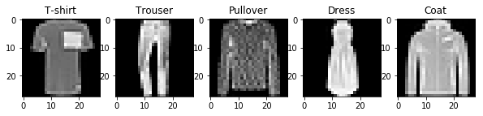

```python
%matplotlib inline

fig, ax = plt.subplots(1, n_classes, figsize=(10,10))

idxs = [np.where(labels == i)[0] for i in range(n_classes)]

for i in range(n_classes):
    k = np.random.choice(idxs[i])
    ax[i].imshow(images[k].reshape(28, 28), cmap="gray")
    ax[i].set_title("{}".format(labels_text[i]))
```

De las 5.000 imágenes distintas utilizaremos 4.000 imágenes para entrenar los diferentes modelos y 1.000 imágenes para validar los resultados. Con el siguiente código separamos los datos que hemos cargado anteriormente en dos conjuntos, train y test, de forma estratificada, es decir, en cada uno de los conjuntos las clases aparecen en la misma proporción que en el conjunto original.

En lugar de trabajar directamente con un vector de 784 dimensiones para cada imagen aplicaremos primero el algoritmo PCA para reducir la dimensión de los ejemplos a 100. El proceso de entrenamiento de PCA lo hacemos con las imágenes de train y luego lo aplicamos también sobre las imágenes de test, de forma que no utilizamos ninguna información de las imágenes en el conjunto de test para entrenar los modelos.

```python
from sklearn.model_selection import train_test_split
from sklearn.decomposition import PCA

X_train, X_test, y_train, y_test = train_test_split(images, labels, test_size=0.2, random_state=2017, stratify=labels)

pca = PCA(n_components=100, random_state=2017)
pca_fit = pca.fit(X_train)
X_train_pca = pca_fit.transform(X_train)
X_test_pca = pca_fit.transform(X_test)

def proporcion_etiquetas(y):
    _, count = np.unique(y, return_counts=True)
    return np.true_divide(count, y.shape[0])


print("Número de imágenes para entrenar: {}".format(X_train_pca.shape[0]))
print("Número de imágenes para test: {}".format(X_test_pca.shape[0]))

print("Proporción de las etiquetas en el conjunto original: {}".format(proporcion_etiquetas(labels)))
print("Proporción de las etiquetas en el conjunto de entrenamiento: {}".format(proporcion_etiquetas(y_train)))
print("Proporción de las etiquetas en el conjunto de test: {}".format(proporcion_etiquetas(y_test)))
```

```
Número de imágenes para entrenar: 4000
Número de imágenes para test: 1000
Proporción de las etiquetas en el conjunto original: [0.2 0.2 0.2 0.2 0.2]
Proporción de las etiquetas en el conjunto de entrenamiento: [0.2 0.2 0.2 0.2 0.2]
Proporción de las etiquetas en el conjunto de test: [0.2 0.2 0.2 0.2 0.2]
```

```python
print("train labels: ", y_train[:5])
```

```
train labels:  [4 4 3 0 2]
```

## 1. $k$ vecinos más cercanos (2 puntos)

El primer algoritmo que utilizaremos para clasificar las imágenes de ropa es el $k$-nn. En este ejercicio ajustaremos dos hiperparámetros del algoritmo:

- $k$: el número de vecinos que se consideran para clasificar un nuevo ejemplo. Probaremos con todos los valores entre 1 y 10.
- pesos: importancia que se da a cada uno de los vecinos considerados. En este caso probaremos dos opciones: pesos uniformes, donde todos los vecinos se consideran igual; y pesos según distancia, donde los vecinos más cercanos tienen más peso en la clasificación que los vecinos más lejanos.

Para decidir cuáles son los hiperparámetros óptimos utilizaremos una búsqueda de rejilla (grid search), es decir, entrenaremos un modelo para cada combinación de hiperparámetros posible y la evaluaremos utilizando validación cruzada (cross validation) con 4 particiones estratificadas. Posteriormente escogeremos la combinación de hiperparámetros que mejor resultados haya dado.

**Implementación:** cálculo del valor óptimo de los hiperparámetros $k$ y pesos. Podéis utilizar los módulos GridSearchCV y KNeighborsClassifier de sklearn.

```python
knn_estimator = neighbors.KNeighborsClassifier()
parameters = {"n_neighbors": range(1, 11), "weights": ('uniform', 'distance')}

grid_searcher = GridSearchCV(estimator=knn_estimator, param_grid=parameters, n_jobs=-1, cv=4)

grid_searcher.fit(X_train, y_train)
```

```
GridSearchCV(cv=4, error_score='raise-deprecating',
       estimator=KNeighborsClassifier(algorithm='auto', leaf_size=30, metric='minkowski',
           metric_params=None, n_jobs=None, n_neighbors=5, p=2,
           weights='uniform'),
       fit_params=None, iid='warn', n_jobs=-1,
       param_grid={'n_neighbors': range(1, 11), 'weights': ('uniform', 'distance')},
       pre_dispatch='2*n_jobs', refit=True, return_train_score='warn',
       scoring=None, verbose=0)
```

**Análisis:** ¿Qué parámetros han dado mejores resultados? ¿Qué variación hay entre las diferentes combinaciones de parámetros? ¿Es significativa la variación entre las diferentes combinaciones? ¿Hay algún parámetro que influya más que el otro? ¿Era de esperar?

```python
print("Los parametros que dan mejores resultados son: %s" % grid_searcher.best_params_)
```

```
Los parametros que dan mejores resultados son: {'n_neighbors': 6, 'weights': 'distance'}
```

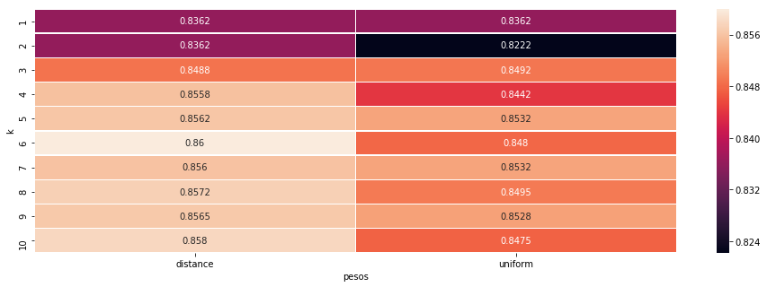

```python
# create a list with the results (parameters plus test_errors)
results_list = [{"k": results[0]["n_neighbors"],
 "pesos": results[0]["weights"],
 "resultados": round(results[1], 4)} for results in zip(grid_searcher.cv_results_["params"], grid_searcher.cv_results_["mean_test_score"])]

# convert list to pandas DataFrame and pivot it to be used in the plot
results_df = pd.DataFrame(results_list)
results_df = results_df.pivot(index='k', columns='pesos', values='resultados')

# create a heatmat with the results
plt.figure(figsize = (16,5))
sns.heatmap(results_df, annot=True, linewidths=.5, fmt='.4g')
```

Se puede observar que el parametro "pesos" tiene una importancia alta en separar los resultados. El numero de vecinos, en numeros bajos tiene una alta influencia, lo cual es de esperar ya que marca mucho el desarrollo del algortimo. Su influencia se diluye a partir de k=5.

**Implementación:** entrenar un modelo $k$-nn con los valores de los hiperparámetros óptimos utilizando todo el conjunto *X_train_pca* y mostrar la precisión de la predicción del modelo en el conjunto *X_test_pca*.

```python
# initialization of the estimator
knn_best_estimator = neighbors.KNeighborsClassifier(**grid_searcher.best_params_)

# fit the estimator using the _pca features
knn_best_estimator.fit(X=X_train_pca, y=y_train)

# get the predictions for the test set
predictions_knn = knn_best_estimator.predict(X_test_pca)
```

```python
# calculate balanced accuracy and confusion matrix for following questions:
balanced_accuracy = balanced_accuracy_score(y_pred=predictions_knn, y_true=y_test)
conf_matrix = confusion_matrix(y_pred=predictions_knn, y_true=y_test)
```

```python
print("La precision balanceada del modelo es: %s" % balanced_accuracy)
```

```
La precision balanceada del modelo es: 0.866
```

**Implementación:** mostrar la matriz de confusión del modelo y algunas imágenes que el modelo haya clasificado incorrectamente junto con la etiqueta asignada por el modelo y la etiqueta original.

```python
def plot_confusion_matrix(cm, classes,
                          normalize=False,
                          title='Confusion matrix',
                          cmap=plt.cm.Blues):
    """
    This function prints and plots the confusion matrix.
    Normalization can be applied by setting `normalize=True`.
    """
    if normalize:
        cm = cm.astype('float') / cm.sum(axis=1)[:, np.newaxis]
        print("Normalized confusion matrix")
    else:
        print('Confusion matrix, without normalization')

    print(cm)

    plt.imshow(cm, interpolation='nearest', cmap=cmap)
    plt.title(title)
    plt.colorbar()
    tick_marks = np.arange(len(classes))
    plt.xticks(tick_marks, classes, rotation=45)
    plt.yticks(tick_marks, classes)

    fmt = '.2f' if normalize else 'd'
    thresh = cm.max() / 2.
    for i, j in itertools.product(range(cm.shape[0]), range(cm.shape[1])):
        plt.text(j, i, format(cm[i, j], fmt),
                 horizontalalignment="center",
                 color="white" if cm[i, j] > thresh else "black")

    plt.ylabel('True label')
    plt.xlabel('Predicted label')
    plt.tight_layout()
```

```
Confusion matrix, without normalization
[[178   0  12   8   2]
 [  1 194   3   2   0]
 [  2   0 160   2  36]
 [ 11   0   2 181   6]
 [  2   0  34  11 153]]
```

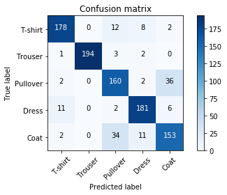

```python
# Compute confusion matrix
np.set_printoptions(precision=2)

# Plot non-normalized confusion matrix
plt.figure()
plot_confusion_matrix(conf_matrix, classes=labels_text)
```

```python
def plot_n_errors_in_test(num_errors, predictions, y_true):

    pred_real_knn = pd.DataFrame(np.column_stack((predictions, y_true)), columns=["pred", "true"])
    error_idx = np.where(pred_real_knn["pred"] != pred_real_knn["true"])[0][0:num_errors]

    fig, ax = plt.subplots(1, num_errors, figsize=(10,10))
    for i, idx in enumerate(error_idx):
        ax[i].imshow(X_test[idx].reshape(28, 28), cmap="gray")
        ax[i].set_title("pred={}".format(labels_dict[str(predictions[idx])]))
```

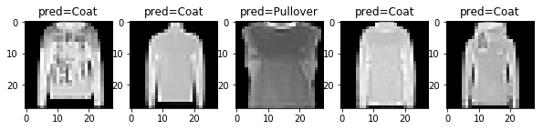

```python
# show some errors
plot_n_errors_in_test(5, predictions_knn, y_true=y_test)
```

**Análisis:** ¿Cómo son los errores? ¿Parecen razonables?

Los errores no son muy desproporcionados. Vemos que la etiqueta *Coat* es a menudo mal clasificada en jerseys, porque comparten son prendas que comparten rasgos similares y las fotos son bastante difusas. Es un modelo mejorable pero que esta cometiendo errores razonables.

## 2. Support Vector Machines (2 puntos)

En este segundo ejercicio clasificaremos las imágenes de ropa utilizando el algoritmo SVM con el kernel radial. En este caso, en lugar de utilizar una búsqueda de rejilla para ajustar los hiperparámetros del algoritmo utilizaremos una búsqueda aleatoria, es decir, probaremos combinaciones de parámetros al azar. Los hiperparámetros a optimizar son:

- C: el valor de penalización de los errores en la clasificación. Marca el compromiso entre obtener el hiperplano con el mayor margen posible y clasificar el máximo número de ejemplos correctamente. Probaremos valores aleatorios distribuidos uniformemente entre 1 y 500.
- gamma: coeficiente que multiplica la distancia entre dos puntos en el kernel radial. Probaremos valores aleatorios distribuidos uniformemente entre 0.001 y 0.1

Igual que en el caso anterior, para validar el rendimiento del algoritmo con cada combinación de hiperparámetros utilizaremos validación cruzada (cross-validation) con 4 particiones estratificadas.

**Implementación:** cálculo del valor óptimo de los hiperparámetros C y gamma utilizando 10 combinaciones de parámetros elegidas al azar. Podéis utilizar los módulos RandomizedSearchCV y svm de sklearn, así como el módulo uniform de scipy.

```python
svm_estimator = svm.SVC(kernel="rbf")
parameter_dist = {"C": uniform(1, 500, 10), "gamma": uniform(0.001, 0.1, 10)}

randomized_grid_searcher = RandomizedSearchCV(svm_estimator, param_distributions=parameter_dist, n_iter=100 , cv=4)
randomized_grid_searcher.fit(X_train, y_train)
```

```
RandomizedSearchCV(cv=4, error_score='raise-deprecating',
          estimator=SVC(C=1.0, cache_size=200, class_weight=None, coef0=0.0,
  decision_function_shape='ovr', degree=3, gamma='auto_deprecated',
  kernel='rbf', max_iter=-1, probability=False, random_state=None,
  shrinking=True, tol=0.001, verbose=False),
          fit_params=None, iid='warn', n_iter=100, n_jobs=None,
          param_distributions={'C': array([ 71.28817, 192.33131, 368.98332, 365.14559, 281.96307, 257.04563,
       383.77219, 153.88667, 278.72332,  88.28342]), 'gamma': array([0.00583, 0.07966, 0.04626, 0.07573, 0.01365, 0.03847, 0.049  ,
       0.09072, 0.06858, 0.07659])},
          pre_dispatch='2*n_jobs', random_state=None, refit=True,
          return_train_score='warn', scoring=None, verbose=0)
```

**Análisis:** ¿Qué parámetros han dado mejores resultados? ¿Qué variación hay entre las diferentes combinaciones de parámetros? ¿Es significativa la variación entre las diferentes combinaciones? ¿Hay algún parámetro que influya más que el otro? ¿Era de esperar?

```python
print("Los parametros que dan mejores resultados son: %s" % randomized_grid_searcher.best_params_)
```

```
Los parametros que dan mejores resultados son: {'gamma': 0.03847360146505251, 'C': 71.28817084434844}
```

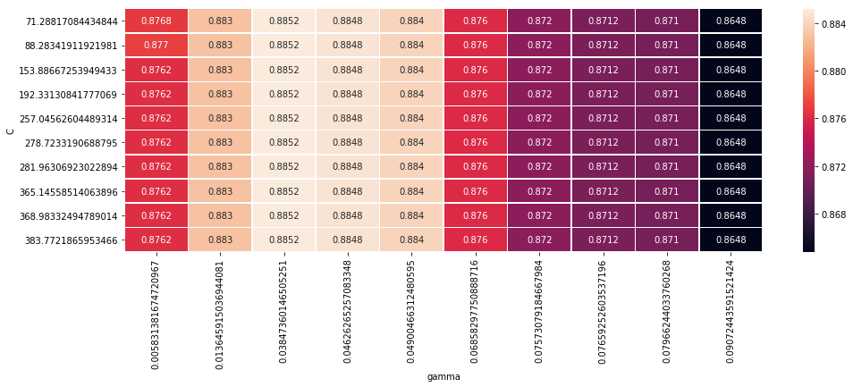

```python
# create a list with the results (parameters plus test_errors)
results_list = [{"C": results[0]["C"],
 "gamma": results[0]["gamma"],
 "resultados": round(results[1], 4)} for results in zip(randomized_grid_searcher.cv_results_["params"],
                                                        randomized_grid_searcher.cv_results_["mean_test_score"])]

# convert list to pandas DataFrame and pivot it to be used in the plot
results_df = pd.DataFrame(results_list)
results_df = results_df.pivot(index='C', columns='gamma', values='resultados')

# create a heatmat with the results
plt.figure(figsize = (16,5))
sns.heatmap(results_df, annot=True, linewidths=.5, fmt='.4g')
```

**Implementación:** entrenar un modelo SVM con los valores de los hiperparámetros óptimos utilizando todo el conjunto *X_train_pca* y mostrar la precisión de la predicción del modelo en el conjunto *X_test_pca*.

```python
# initialization of the estimator
svm_best_estimator = svm.SVC(kernel="rbf", **randomized_grid_searcher.best_params_)

# fit the estimator using the _pca features
svm_best_estimator.fit(X=X_train_pca, y=y_train)

# get the predictions for the test set
predictions_svm = svm_best_estimator.predict(X_test_pca)
```

```python
# calculate balanced accuracy and confusion matrix for following questions:
balanced_accuracy = balanced_accuracy_score(y_pred=predictions_svm, y_true=y_test)
conf_matrix = confusion_matrix(y_pred=predictions_svm, y_true=y_test)
```

```python
print("La precision balanceada del modelo es: %s" % balanced_accuracy)
```

```
La precision balanceada del modelo es: 0.873
```

**Implementación:** mostrar la matriz de confusión del modelo y algunas imágenes que el modelo haya clasificado incorrectamente junto con la etiqueta asignada por el modelo y la etiqueta original.

```
Confusion matrix, without normalization
[[180   0   8  11   1]
 [  1 195   1   3   0]
 [  3   0 162   2  33]
 [ 11   4   6 174   5]
 [  1   0  24  13 162]]
```

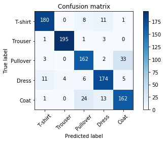

```python
# Compute confusion matrix
np.set_printoptions(precision=2)

# Plot non-normalized confusion matrix
plt.figure()
plot_confusion_matrix(conf_matrix, classes=labels_text)
```

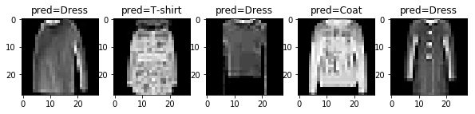

```python
plot_n_errors_in_test(num_errors=5, predictions=predictions_svm, y_true=y_test)
```

**Análisis:** ¿Cómo son los errores? ¿Parecen razonables?

## 3. Redes neuronales (4 puntos)

- Número de neuronas de la capa oculta: probaremos valores entre 20 y 200.
- Número de épocas de entrenamiento: probaremos valores entre 10 y 50.
- Velocidad de aprendizaje (learning rate): probaremos valores entre 0.001 y 0.2.

El procedimiento para validar el rendimiento del modelo para cada combinación de parámetros será el mismo que en los casos anteriores: validación cruzada con 4 particiones generadas de forma estratificada.

**Implementación:** cálculo del valor óptimo del número de neuronas de la capa oculta, el número de épocas de entrenamiento y la velocidad de aprendizaje utilizando 10 combinaciones de parámetros elegidas al azar. Podéis utilizar los módulos Sequential, Dense y SGD de keras, además de uniform y randint de scipy y StratifiedKFold de sklearn.

En el ejercicio se pide aplicar una red *fully connected* para compararla con los metodos tradicionales.

Por profundizar un poco mas he optado por anhadir a la capa densa propuesta un *stack* convolucional (convolucion + _batch*normalization* + activation + *pooling*) implementada en pytorch (https://pytorch.org/docs/0.2.0/nn.html#conv2d). De esta manera podemos ver si este tipo de red mejoran notablemente la precision frente a los metodos empleados en los apartados previos. NOTA: debido a los tiempos de ejecucion (y a que no tenia una GPU en la que entrenar las 10 redes) he limitado la arquitectura a una unica convolucion. En pruebas previas a ejecutar el *notebook* final, se mostraba que al anhadir un segundo *stack* convolucional los resultados mejoraban considerablemente obteniendo precisiones de 90%.

```python
import numpy as np
import torch
import torch.nn as nn
import torch.nn.functional as F
from torch.autograd import Variable
from torch.utils.data import DataLoader
from torch.nn import CrossEntropyLoss


class CNN(nn.Module):

    _loss_function = None
    _optimizer = None
    optimizer = None

    def __init__(self, n_channels_out, n_output, inputCols=None, outputCol=None, optimizer=None, loss_function=None):
        super(CNN, self).__init__()

        self.features_names = inputCols
        self.target_name = outputCol
        self._optimizer = optimizer
        self._loss_function = loss_function

        self.conv_1 = nn.Sequential(
            nn.Conv2d(1, n_channels_out, kernel_size=5, padding=2),
            nn.BatchNorm2d(n_channels_out),
            nn.ReLU(),
            nn.MaxPool2d(2))

        self.linear_out = nn.Linear(14 * 14 * n_channels_out, n_output)

    def forward(self, features_tensor):
        out = self.conv_1(features_tensor)
        out = out.view(out.size(0), -1)
        out = self.linear_out(out)
        out = F.log_softmax(out)

        return out

    def set_loss_function(self, loss_function):
        self._loss_function = loss_function
        return self

    def set_optimizer(self, optimizer, **args):
        if self._optimizer is None:
            self._optimizer = optimizer
        else:
            _optimizer = optimizer(**args)
            self.optimizer = _optimizer
        return self

    def build_net(self, loss_function, optimizer):
        return self.set_loss_function(loss_function).set_optimizer(optimizer)

    def setInputCol(self, inputCols):
        self.features_names = inputCols

    def setOutputCol(self, outputCol):
        self.target_name = outputCol

    def fit(self, train_df, batch_size=64, num_epochs=1, init_lr=0.01):

        if not self.features_names or not self.target_name:
            raise Exception("Target and feature columns must be set before training")

        tensor_dataset = self._get_tensor_dataset(train_df)

        loader = DataLoader(dataset=tensor_dataset, batch_size=batch_size, shuffle=True)

        losses = []
        for epoch in range(num_epochs):
            if epoch % 10 == 0:
                print("epoch {0}/{1}".format(epoch, num_epochs))

            self.set_optimizer(self._optimizer, params=self.parameters(), lr=init_lr)

            for i, (images, labels) in enumerate(loader):
                images = Variable(images.float())
                labels = Variable(labels.long())

                loss = self._forward_pass(images, labels)

                loss.backward()

                # gradient calculation
                self.optimizer.step()

                losses.append(loss.item())
                if (i+1) % 100 == 0:
                    print('Epoch : %d/%d, Iter : %d/%d,  Loss: %.4f' % (epoch+1, num_epochs, i+1, len(tensor_dataset)//batch_size, loss.data[0]))

        return self

    def _get_tensor_dataset(self, train_df):

        features_df = train_df[self.features_names]
        features_tensor = torch.Tensor(features_df.reshape(-1, 1, 28, 28)).float()

        target_df = train_df[self.target_name]
        target_tensor = torch.Tensor(target_df)

        return torch.utils.data.TensorDataset(features_tensor, target_tensor)

    def _forward_pass(self, features, label):
        # restart the gradient calculations
        self.optimizer.zero_grad()

        # Forward pass
        outputs = self(features)

        # calculate the loss function
        criterion = self._loss_function()
        loss = criterion(outputs, label)

        return loss

    def predict(self, features):
        features_tensor = torch.Tensor(features.reshape(-1, 1, 28, 28))

        predictions = np.argmax(F.log_softmax(self(features_tensor)).data.numpy(), axis=1)

        return predictions
```

```python
parameter_dist = {"lr": uniform(0.001, 0.2, 10), "num_epochs": uniform(5, 50, 10), "n_channels_out":uniform(8, 200, 10)}
```

```python
X = np.concatenate((X_train, X_test))
y = np.concatenate((y_train, y_test))

skf = StratifiedKFold(n_splits=10, random_state=2017)
skf.get_n_splits(X, y)

best_parameters = {}
best_accuracy = 0
best_cnn = None

for i, (train_index, test_index) in enumerate(skf.split(X, y)):

    X_train_split = X[train_index]
    y_train_split = y[train_index]
    X_test_split = X[test_index]
    y_test_split = y[test_index]
    images_train = {"images": X_train_split, "labels": y_train_split}

    lr = parameter_dist["lr"][i]
    num_epochs = int(parameter_dist["num_epochs"][i])
    n_channels_out = int(parameter_dist["n_channels_out"][i])


    cnn = CNN(n_channels_out=n_channels_out, n_output=5,
              inputCols="images", outputCol="labels").build_net(optimizer=torch.optim.Adam,
                                                                loss_function=CrossEntropyLoss)
    cnn.fit(images_train, batch_size=64, num_epochs=num_epochs, init_lr=lr)

    predictions = cnn.predict(X_test_split)

    # calculate balanced accuracy and confusion matrix for following questions:
    balanced_accuracy = balanced_accuracy_score(y_pred=predictions, y_true=y_test_split)

    if best_accuracy < balanced_accuracy:
        best_accuracy = balanced_accuracy
        best_parameters = {"lr": lr, "num_epochs": num_epochs, "n_channels_out": n_channels_out}
        best_cnn = cnn

    print("La precision balanceada del modelo (lr={}, num_epochs={}, n_channels_out={}) es: {}".format(
        round(lr, 4), num_epochs, n_channels_out, 100*balanced_accuracy))
```

```
epoch 0/14
```

```
epoch 10/14
```

```
La precision balanceada del modelo (lr=0.1563, num_epochs=14, n_channels_out=161) es: 20.0
epoch 0/23
epoch 10/23
epoch 20/23
La precision balanceada del modelo (lr=0.0706, num_epochs=23, n_channels_out=88) es: 83.80000000000001
epoch 0/29
epoch 10/29
epoch 20/29
La precision balanceada del modelo (lr=0.1304, num_epochs=29, n_channels_out=197) es: 77.2
epoch 0/40
epoch 10/40
epoch 20/40
epoch 30/40
La precision balanceada del modelo (lr=0.0527, num_epochs=40, n_channels_out=151) es: 86.4
epoch 0/25
epoch 10/25
epoch 20/25
La precision balanceada del modelo (lr=0.0638, num_epochs=25, n_channels_out=135) es: 82.19999999999999
epoch 0/23
epoch 10/23
epoch 20/23
La precision balanceada del modelo (lr=0.1646, num_epochs=23, n_channels_out=41) es: 20.0
epoch 0/16
epoch 10/16
La precision balanceada del modelo (lr=0.1255, num_epochs=16, n_channels_out=178) es: 82.99999999999999
epoch 0/6
La precision balanceada del modelo (lr=0.1751, num_epochs=6, n_channels_out=151) es: 20.0
epoch 0/14
epoch 10/14
La precision balanceada del modelo (lr=0.0372, num_epochs=14, n_channels_out=142) es: 88.4
epoch 0/18
epoch 10/18
La precision balanceada del modelo (lr=0.1234, num_epochs=18, n_channels_out=157) es: 20.0
```

**Análisis:** ¿Qué parámetros han dado mejores resultados? ¿Qué variación hay entre las diferentes combinaciones de parámetros? ¿Es significativa la variación entre las diferentes combinaciones? ¿Hay algún parámetro que influya más que los otros? ¿Era de esperar?

```python
print("Los parametros que dan mejores resultados son: %s" % best_parameters)
```

```
Los parametros que dan mejores resultados son: {'lr': 0.03722254220096421, 'num_epochs': 14, 'n_channels_out': 142}
```

Si observamos la lista de las ejecuciones vemos un patron claro: el parametro con mas peso en los resultados finales es la **velocidad de entrenamiento** (*learning rate*). Este resultado es logico puesto que dado como estamos entrenando la red neuronal, con un *lr* alto la velocidad de convergencia puede ser mas rapida, pero tambien el riesgo de saltar de minimo local en minimo local o de que el gradiente se desvie del minimo global. Por norma general la estrategia que mejor funciona es comenzar las primeras *epochs* de la red con un *lr* "alto" (0.1-0.05) afinar los pesos de las capas, y comenzar a reducir gradualmente el *lr* con la reduccion de los errores de la metrica. Este metodo es conocido como *adaptative learning rate training* (https://towardsdatascience.com/learning-rate-schedules-and-adaptive-learning-rate-methods-for-deep-learning-2c8f433990d1).

Por otro lado, vemos que una combinacion de *lr* mas ajustado y un ligero aumento de las *epochs* da buenos resultados. El tamanho de las capas internas no tienen tanta relevancia ya que es un dataset pequenho y la red es capaz de aprender en arquitecturas simples.

Vamos a limitar el experimento a los parametros propuestos, sin embargo, los resultados apuntan que si dejaramos el intervalo de *learning rates* a [0.05 - 0.001], un numero de epochs entre [25-50] y un numero de *channels* entre [60-200] podriamos obtener unos resultados prometedores con una estructura sencilla.

**Implementación:** entrenar una red neuronal con los valores de los hiperparámetros óptimos utilizando todo el conjunto *X_train_pca* y mostrar la precisión de la predicción del modelo en el conjunto *X_test_pca*.

NOTA: Dada la arquitectura construida no tiene mucho sentido entrenar con el dataset transformado por PCA. Si hubiera construido una red neuronal simple como la que se proponia, entonces si, porque podriamos comparar como la red se entrena con los 700+ features o los 100 reducidos. Sin embargo, al usar una red convolucional pretendemos capturar las relaciones espaciales de los pixeles para explicar e interpretar las imagenes. Por ello al reducir el espacio de pixeles y proyectarlo en uno de menor dimensionalidad "perdemos" informacion para que las convoluciones capturen. Es de esperar que los resultados sean diferentes y probablemente peores que con la dataset original.

```python
class CNN_pca(CNN):

    def __init__(self, n_channels_out, n_output, inputCols=None, outputCol=None, optimizer=None, loss_function=None):
        super(CNN_pca, self).__init__(n_channels_out, n_output, inputCols=inputCols, outputCol=outputCol, optimizer=optimizer,
                                  loss_function=loss_function)
        self.linear_out = nn.Linear(4 * 4 * n_channels_out, n_output)

    def _get_tensor_dataset(self, train_df):

        features_df = train_df[self.features_names]
        features_tensor = torch.Tensor(features_df.reshape(-1, 1, 10, 10)).float()

        target_df = train_df[self.target_name]
        target_tensor = torch.Tensor(target_df)

        return torch.utils.data.TensorDataset(features_tensor, target_tensor)

    def forward(self, features_tensor):
        out = self.conv_1(features_tensor)
        out = out.view(out.size(0), -1)
        out = self.linear_out(out)
        out = F.log_softmax(out)

        return out

    def predict(self, features):
        features_tensor = torch.Tensor(features.reshape(-1, 1, 10, 10))

        predictions = np.argmax(F.log_softmax(self(features_tensor)).data.numpy(), axis=1)

        return predictions
```

```python
images_train = {"images": X_train_pca, "labels": y_train}

cnn_pca = CNN_pca(n_channels_out=best_parameters["n_channels_out"],
          n_output=5, inputCols="images", outputCol="labels").build_net(optimizer=torch.optim.Adam,
                                                                        loss_function=CrossEntropyLoss)

cnn_pca.fit(images_train, batch_size=64, num_epochs=best_parameters["num_epochs"], init_lr=best_parameters["lr"])

predictions_cnn_pca = cnn_pca.predict(X_test_pca)

# calculate balanced accuracy and confusion matrix for following questions:
balanced_accuracy = balanced_accuracy_score(y_pred=predictions_cnn_pca, y_true=y_test)
conf_matrix = confusion_matrix(y_pred=predictions_cnn_pca, y_true=y_test)

print("La precision balanceada del modelo es: %s" % balanced_accuracy)
```

[output not shown]

[output not shown]

**Implementación:** mostrar la matriz de confusión del modelo y algunas imágenes que el modelo haya clasificado incorrectamente junto con la etiqueta asignada por el modelo y la etiqueta original.

```
Confusion matrix, without normalization
[[183   0  12   4   1]
 [  2 196   1   1   0]
 [  4   1 178   3  14]
 [ 10  12   7 165   6]
 [  0   0  56  15 129]]
```

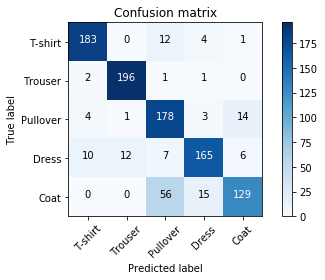

```python
# Compute confusion matrix
np.set_printoptions(precision=2)

# Plot non-normalized confusion matrix
plt.figure()
plot_confusion_matrix(conf_matrix, classes=labels_text)
```

```python
predictions_cnn = best_cnn.predict(X_test)

# calculate balanced accuracy and confusion matrix for following questions:
balanced_accuracy = balanced_accuracy_score(y_pred=predictions_cnn, y_true=y_test)
conf_matrix = confusion_matrix(y_pred=predictions_cnn, y_true=y_test)
```

```
Confusion matrix, without normalization
[[184   1   4  10   1]
 [  0 197   1   1   1]
 [  1   0 177   0  22]
 [  2   6   5 182   5]
 [  0   0  21  15 164]]
```

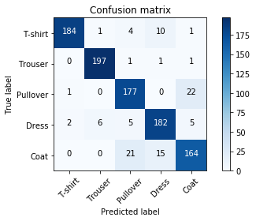

```python
# Compute confusion matrix
np.set_printoptions(precision=2)

# Plot non-normalized confusion matrix
plt.figure()
plot_confusion_matrix(conf_matrix, classes=labels_text)
```

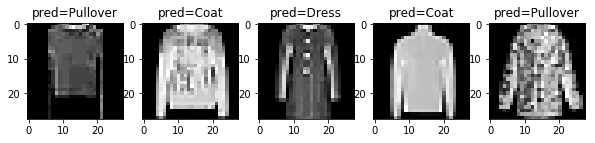

```python
plot_n_errors_in_test(5, predictions_cnn_pca, y_test)
```

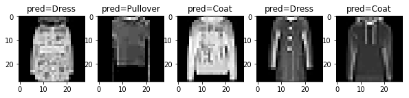

```python
plot_n_errors_in_test(5, predictions_cnn, y_test)
```

**Análisis:** ¿Cómo son los errores? ¿Parecen razonables?

Vemos que los errores son similares a los encontrados en los modelos tradicionales. Es interesante observar que la red con los *features* del PCA invierte el error entre *pullovers* y *coats*. Esto acentua aun mas la similud entre las prendas: al proyectar los pixeles a un espacio reducido estas dos etiquetas dismuyen aun mas su distancia.

En el caso de la red neuronal completa vemos que reduce el numero de errores entre *coats* y *pullovers* pero sin embargo siguen siendo los mas numerosos.

## 4. Optimización de métricas (2 puntos)

En los ejercicios anteriores hemos buscado siempre el modelo que mejor precisión obtiene en general, pero esto no es siempre los más adecuado. Por ejemplo, imaginemos que necesitamos el modelo para una empresa que únicamente vende pantalones y está haciendo un estudio sobre las imágenes de pantalones que obtiene de Internet. En este escenario, imaginemos que la empresa quiere estudiar el máximo número posible de imágenes de pantalones, por lo que está muy interesada en que el modelo no clasifique erróneamente imágenes de pantalones (asumiendo si es necesario que para ello habrá imágenes clasificadas como pantalones que en realidad no lo sean).

La misma idea de utilidad del modelo se puede encontrar, aunque con un ejemplo más complejo, en [este enlace](http://blog.mldb.ai/blog/posts/2016/01/ml-meets-economics/).

**Implementación:** Definir una función que, dada la predicción del modelo para un conjunto de imágenes y las etiquetas reales de los datos, devuelva un coste de forma que los errores de clasificar un pantalón como otra prenda tengan el doble de peso que los otros errores.

NOTA: vamos a implementar la metrica usando numpy. Pero para el entrenamiento de la red, la metrica empleada `CrossEntropyLoss` tiene un parametro *weights* que permite expresar esa diferencia de peso en los errores durante la propagacion del gradiente. Esta metrica emplea el logaritmo de la *softmax* por lo que es optima para el caso de uso que nos ocupa y ya esta optimizada para ser derivable.

```python
WEIGHTS = [1, 2, 1, 1, 1]

def custom_metric(a):
    """Average first and last element of a 1-D array"""
    return WEIGHTS[a[0]] * (a[0] == a[1])

np.sum(np.apply_along_axis(custom_metric, 1, np.column_stack((y_test, predictions_cnn))))
```

```
1101
```

**Implementación:** Utilizar la función definida anteriormente junto con el código de entrenamiento de la red neuronal para optimizar los hiperparámetros de la red según la nueva métrica.

```python
custom_weights = torch.Tensor(WEIGHTS)


class WeightedCNN(CNN):
    """
    Instead of refactoring the class so that upon initialization we pass the loss with the weights let's
    overwrite the method where it's called and set the weights there.
    Not the cleanest implementation but it does the job
    """

    def _forward_pass(self, features, label):
        # restart the gradient calculations
        self.optimizer.zero_grad()

        # Forward pass
        outputs = self(features)

        # calculate the loss function
        loss = CrossEntropyLoss(weight=custom_weights)

        loss = loss(outputs, label)

        return loss
```

```python
X = np.concatenate((X_train, X_test))
y = np.concatenate((y_train, y_test))

skf = StratifiedKFold(n_splits=10, random_state=2017)
skf.get_n_splits(X, y)

best_parameters = {}
best_accuracy = 0
best_cnn = None

for i, (train_index, test_index) in enumerate(skf.split(X, y)):

    X_train_split = X[train_index]
    y_train_split = y[train_index]
    X_test_split = X[test_index]
    y_test_split = y[test_index]
    images_train = {"images": X_train_split, "labels": y_train_split}

    lr = parameter_dist["lr"][i]
    num_epochs = int(parameter_dist["num_epochs"][i])
    n_channels_out = int(parameter_dist["n_channels_out"][i])

    weighted_cnn = WeightedCNN(n_channels_out=n_channels_out, n_output=5,
                               inputCols="images", outputCol="labels").build_net(optimizer=torch.optim.Adam,
                                                                                 loss_function=CrossEntropyLoss)
    weighted_cnn.fit(images_train, batch_size=64, num_epochs=num_epochs, init_lr=lr)

    predictions = weighted_cnn.predict(X_test_split)

    # calculate balanced accuracy and confusion matrix for following questions:
    balanced_accuracy = balanced_accuracy_score(y_pred=predictions, y_true=y_test_split)

    if best_accuracy < balanced_accuracy:
        best_accuracy = balanced_accuracy
        best_parameters = {"lr": lr, "num_epochs": num_epochs, "n_channels_out": n_channels_out}
        best_cnn = weighted_cnn

    print("La precision balanceada del modelo (lr={}, num_epochs={}, n_channels_out={}) es: {}".format(
        round(lr, 4), num_epochs, n_channels_out, 100*balanced_accuracy))
```

```
epoch 0/14
```

```
epoch 10/14
```

```
La precision balanceada del modelo (lr=0.1563, num_epochs=14, n_channels_out=161) es: 20.0
epoch 0/23
epoch 10/23
epoch 20/23
La precision balanceada del modelo (lr=0.0706, num_epochs=23, n_channels_out=88) es: 84.60000000000001
epoch 0/29
epoch 10/29
epoch 20/29
La precision balanceada del modelo (lr=0.1304, num_epochs=29, n_channels_out=197) es: 81.19999999999999
epoch 0/40
epoch 10/40
epoch 20/40
epoch 30/40
La precision balanceada del modelo (lr=0.0527, num_epochs=40, n_channels_out=151) es: 87.19999999999999
epoch 0/25
epoch 10/25
epoch 20/25
La precision balanceada del modelo (lr=0.0638, num_epochs=25, n_channels_out=135) es: 89.4
epoch 0/23
epoch 10/23
epoch 20/23
La precision balanceada del modelo (lr=0.1646, num_epochs=23, n_channels_out=41) es: 20.0
epoch 0/16
epoch 10/16
La precision balanceada del modelo (lr=0.1255, num_epochs=16, n_channels_out=178) es: 20.0
epoch 0/6
La precision balanceada del modelo (lr=0.1751, num_epochs=6, n_channels_out=151) es: 55.00000000000001
epoch 0/14
epoch 10/14
La precision balanceada del modelo (lr=0.0372, num_epochs=14, n_channels_out=142) es: 86.4
epoch 0/18
epoch 10/18
La precision balanceada del modelo (lr=0.1234, num_epochs=18, n_channels_out=157) es: 83.2
```

**Análisis:** ¿Han cambiado significativamente los mejores valores de los hiperparámetros? ¿Cuál crees que puede ser la razón?

```python
print("Los parametros que dan mejores resultados son: %s" % best_parameters)
```

```
Los parametros que dan mejores resultados son: {'lr': 0.06383553559589722, 'num_epochs': 25, 'n_channels_out': 135}
```

Vemos que efectivamente los parametros han cambiado. No significativamente, pero con esta configuracion el modelo ha "afinado" los parametros de la red para ajustarse al nuevo requerimiento. Vamos a visualizar la matriz de confusion para ver si se nota en la precision de los *trousers*

```
Confusion matrix, without normalization
[[173   0   6  15   6]
 [  0 200   0   0   0]
 [  2   0 164   1  33]
 [  2   1   2 191   4]
 [  0   0  14  10 176]]
```

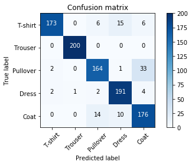

```python
predictions_weighted_cnn = best_cnn.predict(X_test)

# calculate balanced accuracy and confusion matrix for following questions:
balanced_accuracy = balanced_accuracy_score(y_pred=predictions_weighted_cnn, y_true=y_test)
conf_matrix = confusion_matrix(y_pred=predictions_weighted_cnn, y_true=y_test)

# Compute confusion matrix
np.set_printoptions(precision=2)

# Plot non-normalized confusion matrix
plt.figure()
plot_confusion_matrix(conf_matrix, classes=labels_text)
```